[figure not shown]

# Allan's Portfolio

#### Main

#### Projects

#### Resume

# Time Series Analysis: Home Sales

**Introduction.** The study was conducted on time series data of the monthly total of new onefamily home sales in the US. The span of the series begins in 1973 extending until November of 1995. For this duration, at least 24 houses were sold from month to month reaching a maximum of 89 homes sold. On average, approximately 52 were sold, and the median was 53 homes sold. *Figure 1* shows a visual representation of the data, and it is immediately apparent that any rises in sales is immediately followed by a drop in sales, or that strong positive correlation is followed by negative correlation. It appears to be an ongoing pattern. The two main goals are to find any significant seasonal effects on sales and to determine a reasonable one-year forecast.

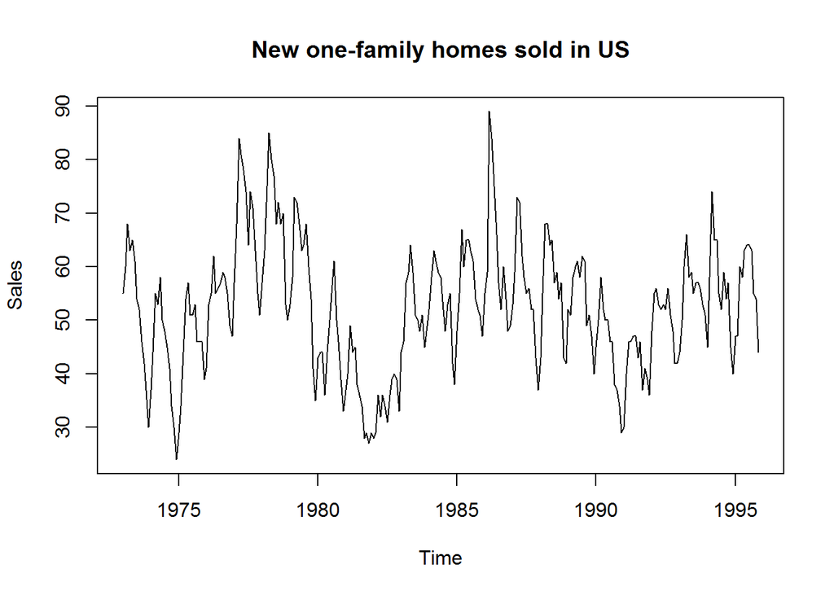

*Figure 1*

**Examining Periodic Effects.** The first step to finding any seasonal effects for home sales would be to locate patterns that stand out and determine if they are significant or not. This time series is composed of several different periodic effects, as shown by its spectral density in *Figure 2a.* Specifically, there are three cycles present by observing the ordinates computed exactly as an 8year cycle, a 1-year cycle, and a 6-month cycle. Returning to *Figure 1*, starting at 1975 and following the graph to around 1983 and again to 1991 does show an 8-year cyclical pattern. Similarly, the aforementioned rising and falling of sales indicates that there is a 1-year cycle occurring. The 6-month pattern indicates an effect that happens somewhere during the year. Each of these periodic components were tested for significance, shown in *Figure 2b-d*. A 95% confidence interval was constructed for each of the peaks to find if most of the remaining frequencies fall below it, and the blue line represents the lower bound for each frequency. Both the 8 and 1-year cycle show obvious significance, however the 6-month effect is somewhat difficult to tell just by looking at the graph. Approximately 94% of the other frequencies fall below this line, so it reasonable to say that the 6-month cycle is also significant and should be considered in the overall assessment.

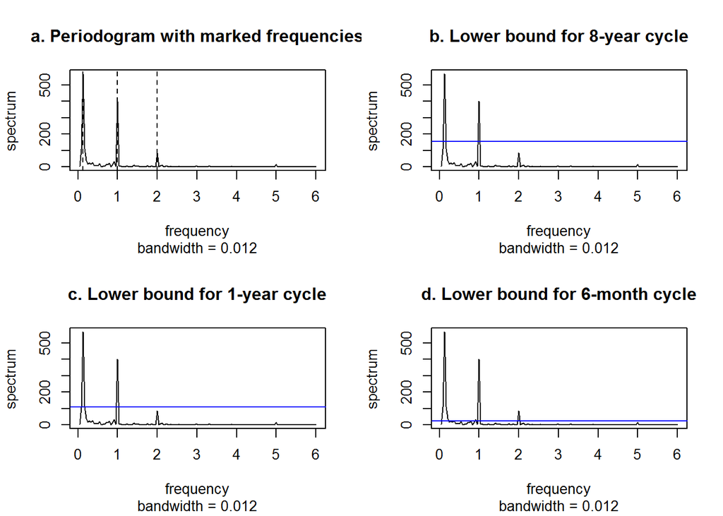

*Figure 2 a. The dashed lines indicate the frequencies with an effect on sales. b. From a 95% C.I., the lower bound for the 8-year cycle. c. From a 95% C.I., the lower bound for a 1-year cycle. d. From a 95% C.I., the lower bound for a 6-month cycle. About 94% of the ordinates fell below this line.*

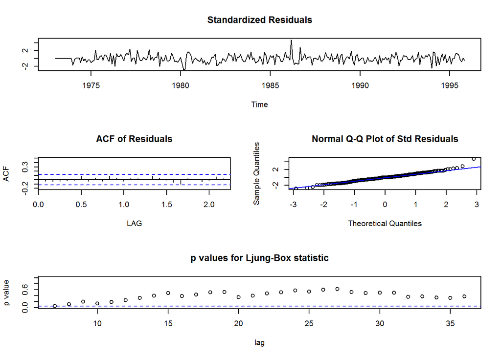

*Figure 3*

**Forecasting.** Using the fitted ARIMA model, a 1-year forecast was calculated from December of 1995 to November of 1996. Since with each additional time point they will tend more and more to the average home sales, projecting only a year seemed most reasonable. It also is most pertinent due to the fact that the immediate proceeding year is the market that would matter most. The following table shows the forecasted values for each month while also including their 95% prediction intervals. For brevity, home sales were rounded to the nearest sale.

[output not shown]

These values are included in *Figure 4*, which displays a portion of the end of the time series followed by the forecasts, in blue. The red lines indicate the prediction interval which grows wider in time, a result of higher variability with further time points.

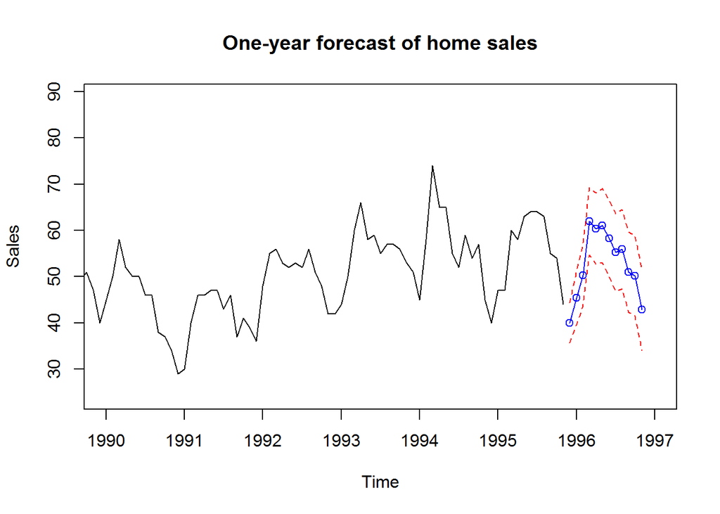

*Figure 4*

**Conclusions.** With the three periodic components (found to be significant) present in the time series, they can help describe where in the cycle the time series at any given point is, as well as what to expect for the following year. The 8-year effect shows that following a local minimum, a peak is eventually reached, only to be followed by another local minimum returning to the cycle. In the current cycle, that peak should have already occurred leading to a downward trend that is expected to continue until 1999. The 1-year effect sees that there is always a rise and fall of home sales cycle that is exhibited annually. When this is coupled with the 6-month effect, there appears to be a steep rise until about the month of March, then gradually falls until January of the next year. The time series leaves off on November, and so the subsequent forecasted point is not surprisingly the lowest point of sales in 1995. Going into 1996, the months of January through May seem to be a reasonable representation of what to expect sales to be in that time. However there is a large degree of uncertainty as to what the peak sales will be in March. This same notion holds as the sales decrease later in the year. The general shape is the same, and at the very least the high points and low points of the year can be easily anticipated. March is the peak month, and indeed the absolute maximum in the time series occurred in this month. From there, similarly high sales are expected which will then drop off after June. The prediction intervals may give some hope as to having higher sales in 1996 than in 1995. However, considering the 8-year cycle, the highest yearly peak has already been reached in the current one, and all following yearly peaks should be moving downward until 1999. Therefore, the chance of this happening is unlikely. This shows the importance of including all periodic effects during assessment, as the 1-year cycle indicates that there will always be a high point in the year, but the 8-year cycle helps show where that peak will be. If anything, the highest yearly peak in the current 8-year cycle is well below that of the previous two which may mean there could be a slight leveling off period about to occur. Forecasting that far would not give accurate results, so it is better to consider only the next year.

[figure not shown]